# MARS

Coreys Notes

# 1 Mars

Uses surrogate features that are two contrasted versions of a predictor to enter the model. The surrogate features are generally only a function of one or two predictors at a time. Creates cut-points that are called hinges. Creates a piece wise linear model where each new feature models an isolated portion of the original data. Cut-points are chosen at the point that achieves the smallest error.

example:

h(x)=x if x>0, 0 if x<0

-5 + 2.1 * h(x1-5.9) + 3 * h(5.9-x1)

After the hinge functions are created, the GCV statistic is used to prune the model.

Tuning parameters: degree of the features, if one then it is additive. Number of retained terms which is found using GCV.

Pros: performs feature selection automatically. Interpretability, each hinge function is responsible for modeling a specific region in the predictor space using a piece wise linear model. When the model is additive, the contribution of each predictor can be isolated without the need to consider the others.

When second degree, the hinge functions are split into two regions, three of the possible four regions will be zero and offer no contribution to the model. Correlated predictors do not drastically effect performance, but can complicate interpretability as which predictor is chosen can be random. RMSE reduction from predictors can be used as a measure of variable importance.

```r
library(dplyr)
library(caret)
library(earth)
train <- read.csv("train.csv")
head(train)
```

```
##   Id MSSubClass MSZoning LotFrontage LotArea Street Alley LotShape LandContour
## 1  1         60       RL          65    8450   Pave  <NA>      Reg         Lvl
## 2  2         20       RL          80    9600   Pave  <NA>      Reg         Lvl
## 3  3         60       RL          68   11250   Pave  <NA>      IR1         Lvl
## 4  4         70       RL          60    9550   Pave  <NA>      IR1         Lvl
## 5  5         60       RL          84   14260   Pave  <NA>      IR1         Lvl
## 6  6         50       RL          85   14115   Pave  <NA>      IR1         Lvl
##   Utilities LotConfig LandSlope Neighborhood Condition1 Condition2 BldgType
## 1    AllPub    Inside       Gtl      CollgCr       Norm       Norm     1Fam
## 2    AllPub       FR2       Gtl      Veenker      Feedr       Norm     1Fam
## 3    AllPub    Inside       Gtl      CollgCr       Norm       Norm     1Fam
## 4    AllPub    Corner       Gtl      Crawfor       Norm       Norm     1Fam
## 5    AllPub       FR2       Gtl      NoRidge       Norm       Norm     1Fam
## 6    AllPub    Inside       Gtl      Mitchel       Norm       Norm     1Fam
##   HouseStyle OverallQual OverallCond YearBuilt YearRemodAdd RoofStyle RoofMatl
```

[output cut: 69 more lines]

```r
train <- train %>% select(YearBuilt,SalePrice,OverallQual,LotArea,MasVnrArea,BsmtQual)
train <- train[complete.cases(train),]
```

# 2 Basic Mars

```r
marsModel <- earth(SalePrice~.,data=train)
marsModel
```

```
## Selected 14 of 15 terms, and 7 of 7 predictors
## Termination condition: Reached nk 21
## Importance: OverallQual, LotArea, MasVnrArea, BsmtQualTA, BsmtQualFa, ...
## Number of terms at each degree of interaction: 1 13 (additive model)
## GCV 1470323474    RSS 2.001868e+12    GRSq 0.7659621    RSq 0.7744898
```

```r
summary(marsModel)
```

```
## Call: earth(formula=SalePrice~., data=train)
##
##                   coefficients
## (Intercept)         252766.066
## BsmtQualFa          -46204.372
## BsmtQualGd          -32472.691
## BsmtQualTA          -42212.556
## h(YearBuilt-1984)     1324.737
## h(YearBuilt-1996)    -3337.225
## h(2007-YearBuilt)     -178.001
## h(YearBuilt-2007)    18554.503
## h(OverallQual-6)     16793.994
## h(7-OverallQual)    -17319.986
## h(OverallQual-7)     33261.746
## h(15750-LotArea)        -5.522
## h(LotArea-15750)         0.517
## h(MasVnrArea-68)        51.312
##
## Selected 14 of 15 terms, and 7 of 7 predictors
## Termination condition: Reached nk 21
## Importance: OverallQual, LotArea, MasVnrArea, BsmtQualTA, BsmtQualFa, ...
## Number of terms at each degree of interaction: 1 13 (additive model)
## GCV 1470323474    RSS 2.001868e+12    GRSq 0.7659621    RSq 0.7744898
```

```
##  plotmo grid:    YearBuilt OverallQual LotArea MasVnrArea BsmtQual
##                       1973           6    9503          0       TA
```

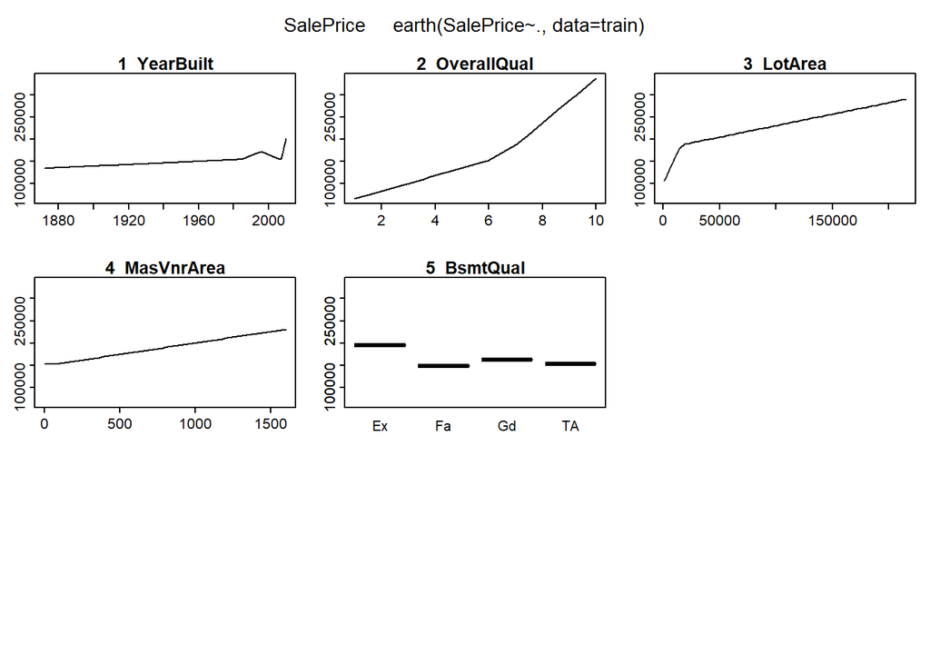

```r
plotmo(marsModel)
```

# 3 With Train

```r
set.seed(342)
myMod <- train(SalePrice~.,data=train,

               method="earth",
               tuneGrid=expand.grid(.degree=c(1,2),.nprune=2:10))

myMod
```

```
## Multivariate Adaptive Regression Spline
##
## 1415 samples
##    5 predictor
##
## No pre-processing
## Resampling: Bootstrapped (25 reps)
## Summary of sample sizes: 1415, 1415, 1415, 1415, 1415, 1415, ...
## Resampling results across tuning parameters:
##
##   degree  nprune  RMSE      Rsquared   MAE
##   1        2      54349.03  0.5442839  39964.28
##   1        3      45943.54  0.6761299  31508.71
##   1        4      42395.66  0.7247489  28654.60
##   1        5      41766.96  0.7335673  27810.44
##   1        6      41573.53  0.7367402  27347.14
##   1        7      41912.64  0.7328251  27345.25
##   1        8      41611.74  0.7370560  27041.26
##   1        9      41562.33  0.7373022  26980.02
##   1       10      41438.22  0.7391788  26790.38
##   2        2      54668.13  0.5385723  40224.33
##   2        3      46022.74  0.6747021  31536.59
##   2        4      42395.66  0.7247489  28654.60
##   2        5      41945.36  0.7303740  27804.16
##   2        6      42457.04  0.7252752  27581.42
##   2        7      42376.16  0.7263747  27463.10
##   2        8      43702.40  0.7098019  27635.21
##   2        9      43717.60  0.7105883  27457.45
##   2       10      43782.56  0.7102934  27393.67
##
## RMSE was used to select the optimal model using the smallest value.
## The final values used for the model were nprune = 10 and degree = 1.
```

```r
summary(myMod)
```

```
## Call: earth(x=matrix[1415,7], y=c(208500,181500...), keepxy=TRUE, degree=1,
##             nprune=10)
##
##                   coefficients
## (Intercept)         263955.337
## BsmtQualFa          -58077.517
## BsmtQualGd          -30632.164
## BsmtQualTA          -51486.575
## h(YearBuilt-2007)    13111.227
## h(7-OverallQual)    -23547.880
## h(OverallQual-7)     52032.461
## h(15750-LotArea)        -5.555
## h(LotArea-15750)         0.479
## h(MasVnrArea-68)        56.619
##
## Selected 10 of 15 terms, and 7 of 7 predictors (nprune=10)
## Termination condition: Reached nk 21
## Importance: OverallQual, LotArea, MasVnrArea, BsmtQualTA, BsmtQualFa, ...
## Number of terms at each degree of interaction: 1 9 (additive model)
## GCV 1504851982    RSS 2.072565e+12    GRSq 0.7604661    RSq 0.7665257
```

```
##  plotmo grid:    YearBuilt OverallQual LotArea MasVnrArea BsmtQual
##                       1973           6    9503          0       TA
```

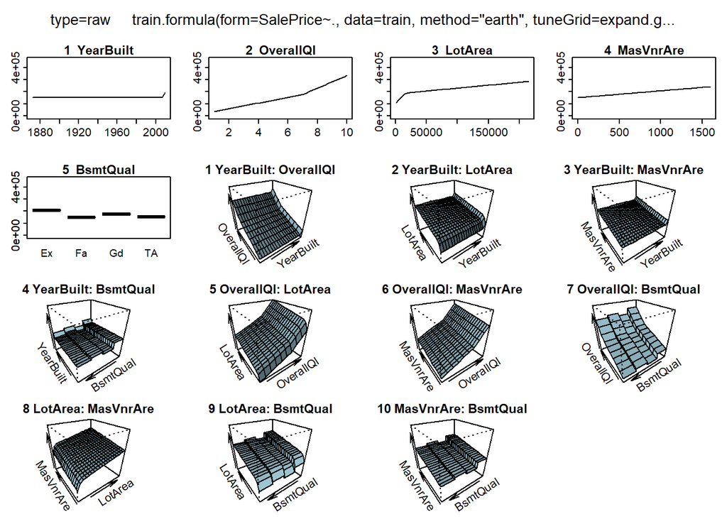

```r
plotmo(myMod)
```

# 4 Variable Importance

```r
varImp(myMod)
```

```
## earth variable importance
##
##             Overall
## OverallQual 100.000
## LotArea      32.220
## MasVnrArea   18.247
## BsmtQualTA   14.148
## BsmtQualFa    9.438
## BsmtQualGd    8.117
## YearBuilt     0.000
```